# eMOLT Update

*eMOLT Update 2023-04-14*

It’s been a busy week for the eMOLT team. We’ve started to roll out the first deckboxes with the new software developed jointly by GOMLF and Lowell Instruments. The first vessels running the new software will be longtime eMOLT participant F/V Tenacious II (a longliner homeported on Cape Cod) and two new additions the F/V Seawatcher I and F/V Seawatcher II, (hydraulic clammers homeported in New Bedford). Thanks to Captain Eric on the Tenacious II and to Seawatch fleet manager Chris and Captain Andy on the Seawatcher I for working with us to test the new boxes. We also spent some time in Sandwich this week, touching base with six eMOLT participants there and troubleshooting systems on the F/Vs Grace Sarah, Charger, and Virginia Marie.

[figure not shown]

For those of you worried that JiM is spending retirement with his feet up sipping fancy coffees, fear not. This past week, we me in JiM’s basement laboratory to check the performance and calibration of many of our temperature probes in a stirred ice-bath, as JiM’s been doing every year in preparation for mailing out probes to long time eMOLT participants. Each time we conduct this operation, we improve our methods. This time, George and Huanxin devised a contraption where the 0.01 degC accurate handheld Fluke thermistor could be monitored via the laptop movie setup. This new method eliminates the need to manually record each observation in realtime. The results of the test are shown below where we compared four different instrument models and found they differed by a few tenths of a degree. We question whether these differences are due to the small 5-gallon bucket vessel and/or the smaller pump used (50 gph). We plan to conduct another test of instruments in the coming weeks including the pressure-triggered models like Creare and Moana in a larger test vessel with a larger pump.

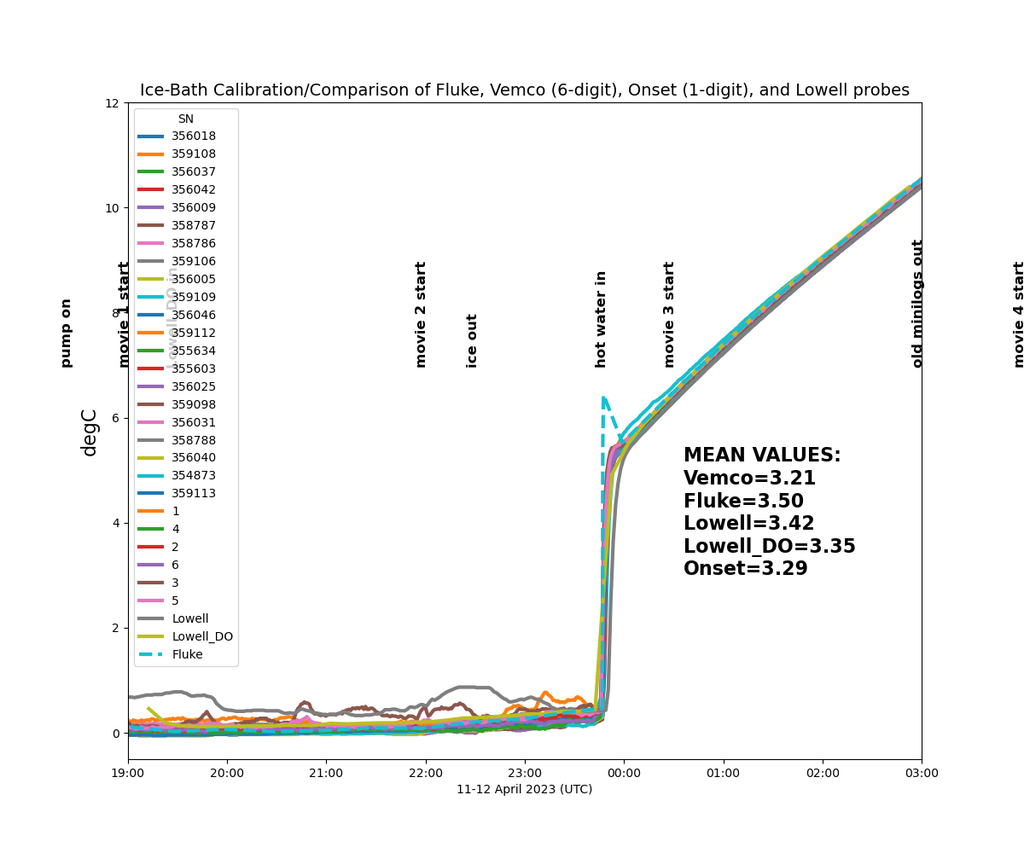

### Realtime Summary (Vessels with Rockblock Satellite Transmitters)

This week, we received 33 haul-averaged reports from 4 vessels.

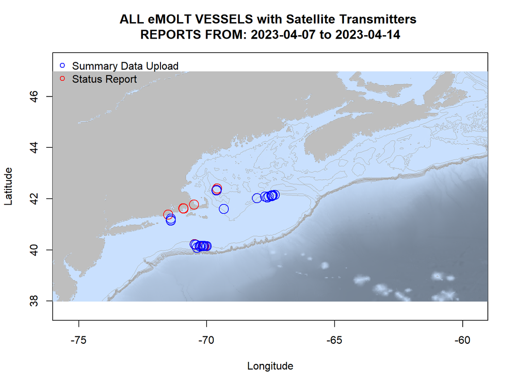

*eMOLT Satellite Transmitter status plot for the previous week.* In the figure above, you can see the approximate locations where we received “Status Reports” (a ping from your system letting us know that it’s still working) and “Data Uploads” (actual temperature / depth data collected by your probes). The “Status Reports” come in every 12 hours or so when a system is powered up. “Data Uploads” only come in when you haul the probes. If you were out fishing and don’t see your approximate locations on here, please reach out because there may be a problem with your system.

### NECOFS Bottom Temperature Forecast

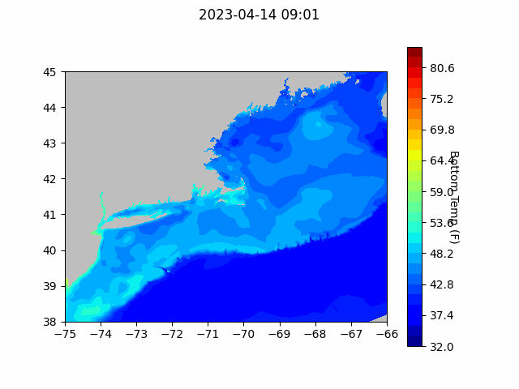

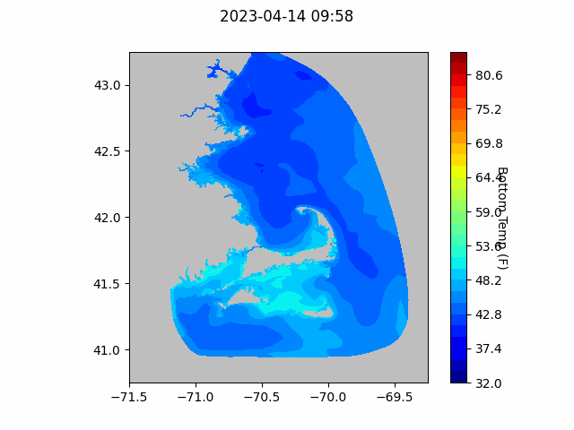

Above, please find the bottom temperature forecasts at one hour intervals from the Northeast Coastal Ocean Forecast System run by the [Chen Lab](http://fvcom.smast.umassd.edu/) at the University of Massachusetts School for Marine Science and Technology in New Bedford. The top panel shows the large scale Northeast model, and the bottom panel shows a higher resolution sub-model for waters around Massachusetts.

As always, please feel free to get in touch if you notice something different out on the water, have any problems with your system, or have suggestions for what we can be doing better.

All the best, George and JiM